# ToothGroth analysis

# description

The response is the length of odontoblasts (cells responsible for tooth growth) in 60 guinea pigs. Each animal received one of three dose levels of vitamin C (0.5, 1, and 2 mg/day) by one of two delivery methods, orange juice or ascorbic acid (a form of vitamin C and coded as VC).

# Format

A data frame with 60 observations on 3 variables.

[,1] len numeric Tooth length [,2] supp factor Supplement type (VC or OJ). [,3] dose numeric Dose in milligrams/day

let’s look at the dataset:

```r
head(ToothGrowth)
```

```
##    len supp dose
## 1  4.2   VC  0.5
## 2 11.5   VC  0.5
## 3  7.3   VC  0.5
## 4  5.8   VC  0.5
## 5  6.4   VC  0.5
## 6 10.0   VC  0.5
```

```r
summary(ToothGrowth)
```

```
##       len        supp         dose
##  Min.   : 4.20   OJ:30   Min.   :0.500
##  1st Qu.:13.07   VC:30   1st Qu.:0.500
##  Median :19.25           Median :1.000
##  Mean   :18.81           Mean   :1.167
##  3rd Qu.:25.27           3rd Qu.:2.000
##  Max.   :33.90           Max.   :2.000
```

the dose is a factor in this dataset so we will set it as factor and look again at the summary:

```r
df<-ToothGrowth
df$dose<-as.factor(df$dose)

summary(df)
```

```
##       len        supp     dose
##  Min.   : 4.20   OJ:30   0.5:20
##  1st Qu.:13.07   VC:30   1  :20
##  Median :19.25           2  :20
##  Mean   :18.81
##  3rd Qu.:25.27
##  Max.   :33.90
```

## Initail Data Exploration

Now let’s explore the data by looking at some plots:

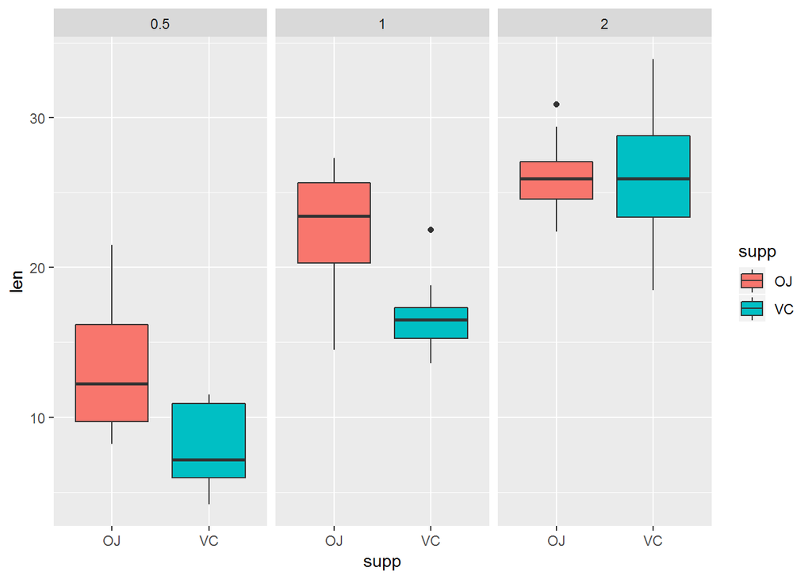

```r
library(ggplot2)
ggplot(data = df,aes(x = supp ,y=len, group =supp))+geom_boxplot(aes(fill = supp))+facet_grid(. ~ dose)
```

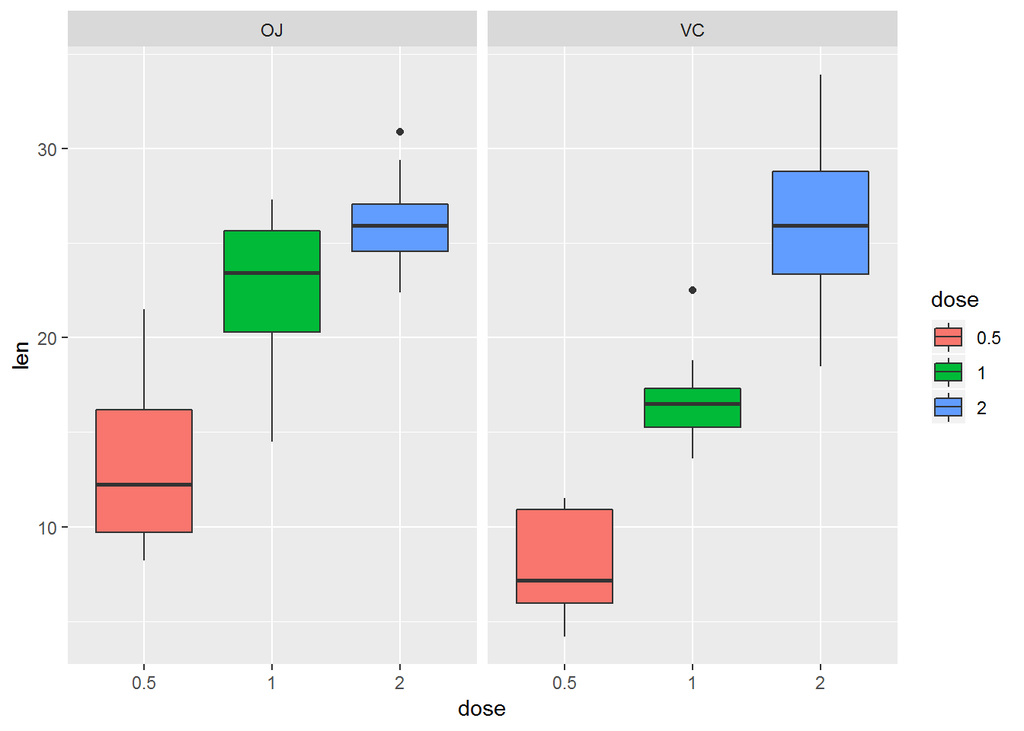

```r
ggplot(data = df,aes(x = dose ,y=len, group =dose))+geom_boxplot(aes(fill = dose))+facet_grid(. ~ supp)
```

## Checking The Hypothesis

Since we saw a big diffrence in the plots between the dosege lets try to use T test to check the hypothesis that higher dosege gives longer teeth. or on other words: H0 = teeth_len(dose_0.5)=teeth_len(dose_1) = teeth_len(dose_2) H1 = teeth_len(dose_0.5)<teeth_len(dose_1) < teeth_len(dose_2)

we are asuming that the underlying data of teeth length is normal to condacte this test. given small amount of data for each test case and the lack of a control group or prior knolagde of the population before the experement this assumption may be wrong.

```r
t.test(df_dose_1 - df_dose_05)$conf
```

```
## [1]  6.387121 11.872879
## attr(,"conf.level")
## [1] 0.95
```

```r
t.test(df_dose_1 - df_dose_05)$p.value
```

```
## [1] 1.225437e-06
```

```r
t.test(df_dose_2 - df_dose_1)$conf
```

```
## [1] 3.471814 9.258186
## attr(,"conf.level")
## [1] 0.95
```

```r
t.test(df_dose_2 - df_dose_1)$p.value
```

```
## [1] 0.0001934186
```

We can see that zero is not in the 95% confidence interval for both cases, so we can reject the null Hypothesis with 95% confidence. additionally we can see that the p-value is very low so we can reject with higher confidence levels as well. based on this data we can conclude that dose of 2 mg/day is better then 0.5 or 1.

Now let’s consider the delivery method. in the initial analysis it was hard to determine visually which method is better overall and which is better for each spesific dose.

let’s check whether there is a segnifecant diffrence for the delivery method. we will do a similar t test. first we will check if there is a diffrence over the entire population and then we will look only in the 2 mg/day dose since this was the leading dose with a segnificent and visible diffrence.

```r
t.test(dfOJ - dfVC)$conf
```

```
## [1] 1.408659 5.991341
## attr(,"conf.level")
## [1] 0.95
```

```r
t.test(dfOJ - dfVC)$p.value
```

```
## [1] 0.002549842
```

```r
t.test(df_dose_2_OJ - df_dose_2_VC)$conf
```

```
## [1] -4.328976  4.168976
## attr(,"conf.level")
## [1] 0.95
```

```r
t.test(df_dose_2_OJ - df_dose_2_VC)$p.value
```

```
## [1] 0.9669567
```

the first test shows that over all doseges the Orange Juice is better with 95% confidence but when looking at the dose of 2 mg/day (10 observations for each group) the 95% confidence interval includes 0 (accually 0 is right in the middle) so we can’t reject the null hypothesis.

## Summary

to summrize, given this data the preffered method for getting higher teeth growth is using vitemin C with a dose of 2 mg/day with delivery method of Orange Juice or ascorbic acid.

follow-up reserch seggesstions:

1. what would be the affect of a higher dosege then 2 mg/day?
2. repeat the experiment with larger groups with a control group that dosen’t recive addetives, and 2 groups each getting 2 mg/day half with OJ and the other half with ascorbic acid.
3. conduct a similar exppirement with 2 groups one getting 2 mg/day OJ and the other 2 mg/day VC. in the first part of the expirement no addetive will be given and then in the second part they will be given addetive according to their group. *this way we can control for the natural variance in the population.